# Biblio - notes

M. Rolland

02/07/2020

# DLNM vignettes

> non-linear and delayed effects between predictors and an outcome

> The general idea is toweightpast exposures through specific functions whose parameters are estimated by the data.

Two dimensional relationship between exposure-lag-outcome:

- x = exposure
- y = lag
- z = outcome

To adjust for seasonanility:

> a smooth function of time with 7 df/year (in order to correct for seasonality and long time trend)

> when allowing for a non-linear dependency with temperature, we need to adopt a bi-dimensional perspective in order to represent associations which vary non-linearly along the space of the predictor and lags

# Association of Air Pollution and Heat Exposure With Preterm Birth, Low BirthWeight, and Stillbirth in the US

(Bekkar et al. 2020)

- Systematic review
- 9 of 10 showed a significant association of air pollutant and heat exposure with birth outcomes
- The subpopulations at highest risk were persons with asthma and minority groups, especially black mothers
- There were 5 included studies evaluating the association of maternal exposure to heat with preterm birth (eTable 5 in the Supplement). A total of 4 (80%) found an increased risk.

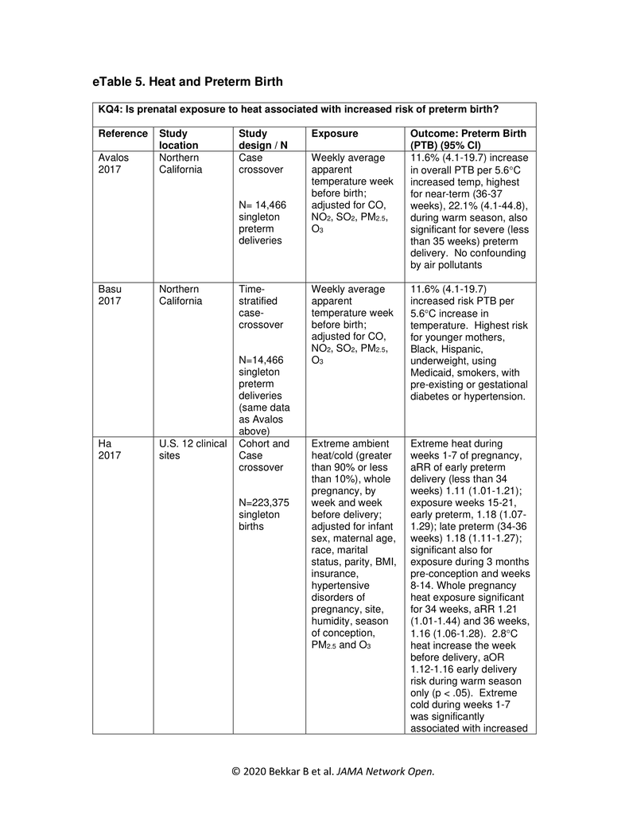

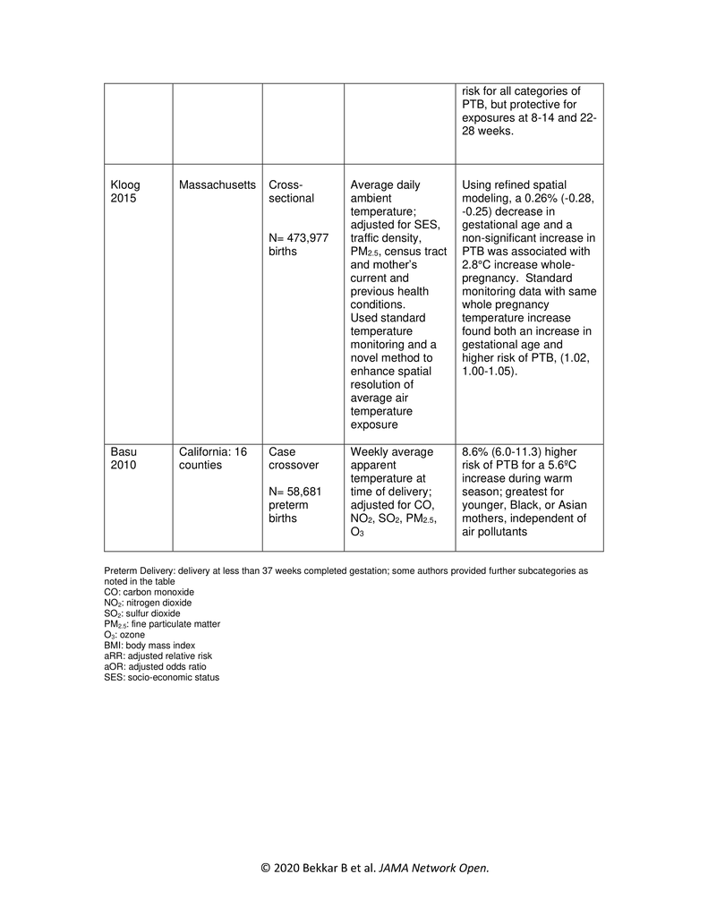

# The association between ambient temperature and the risk of preterm birth in China

(Guo et al. 2018)

- 1,020,471 singleton births were included, of which 73,240 (7.2%) were preterm births
- exposure: city temperature and humidity, average of 91 days pre conception, 1-7 weeks, 8-14 weeks, 145-21 weeks, whole pregnancy, 1 week before delivery, 4 weeks before delivery
- clustering applied to cities for defining their temperature “profile” (used for stratification)
- covariates
  - maternal age
  - body mass index before pregnancy
  - infant sex
  - exposure to alcohol and second hand smoke during pregnancy
  - number of previous pregnancies
  - the month of pregnancy
  - humidity
  - average per capita gross domestic product (GDP) of each city from2010 to 2013
- results
  - strongest link increase of PTB with exposure to high temps in the 3 months preceding pregnancy
  - protective effect of expoure to cold in 3 months preceding pregnancy

# Extreme heat episodes and risk of preterm birth in California, 2005–2013

(Ilango et al. 2020)

- 1,967,300 mothers who had live, singleton births in California, from May through September 2005–2013
- Approximately 7% of the cohort had a preterm birth
- exposure: 12 definitions of extreme heat using varied extremes (75th, 90th, 95th, 98th percentiles) and durations (at least 2, 3, or 4 consecutive days) from estimated maximum temperature data with 6km grid data + participant residential zip code
- covariates
  - maternal age
  - maternal race/ethnicity
  - maternal education
  - maternal health insurance
  - maternal parity
  - sex of infant
  - season of birth
- results:
  - risk of preterm birth was consistently higher among mothers who experienced an extreme heat episode during their last week of gestation
- sensitivity analyses:
  - relative humidity

**Je ne comprends pas leur utilisation du modèle de cox** (regression logistique?)

# The association between ambient temperature and preterm birth in Shenzhen, China: a distributed lag nonlinear time series analysis

(Liang et al. 2016)

- pop: birth registry data base from shenzen 2005-2011, 5.6% PTB
- exp: daily meteorological data for the city, daily average temp
- covariates:
  - indicator for day of week (DOW)
  - an indicator for public holiday (PH)
  - in order to control the seasonal and long-term trends and adjust for nontemperature aspects of weather, a natural cubic spline for day of the year (DOY, with df of 5/year),
  - natural cubic spline of relative humidity (RH) and atmospheric pressure (BP) with the degrees of freedom (5 df ), which was chosen by minimizing the AIC values
  - and the linear function of air pollutants (NO2, PM10, SO2) were introduced into the model simultaneously.
- model:
  - quasi poisson dlnm (count of daily ptb)
  - AIC to choose n knots
- results
  - positive association of low temperature and a negative association of high temperature
- sensitivity: variation of degrees of freedom

**pk juste 30 jours pre birth?**

# Maternal Exposure to Ambient Temperature and the Risks of Preterm Birth and Stillbirth in Brisbane, Australia

(Strand, Barnett, and Tong 2012)

- birth registry of brisbane (aus) 2005 - 2009, n = 101,807
- exp: mean temperature in 4 previous weeks and previous week, no address
- covariates
  - sex of the infant
  - maternal age
  - maternal smoking
  - marital status
  - Indigenous status
  - pregnancy complications (preeclampsia and pregnancy-induced hypertension).
  - Both young and oldmaternal ages have been associated with adverse birth outcomes, so we used a splinewith 3 degrees of freedom to model a nonlinear relation
  - To control for the seasonality of preterm birth and stillbirth, we included the time-dependent variable ‘‘month’’ (using week of gestation from week 15 to birth). We controlled for any long-term trends in gestation or stillbirth by including a spline with 2 degrees of freedom, because we expected any trend over 4 years to be smooth.
  - To avoid problems arising from collinearity from multiple air pollutants, we included one air pollutant at a time in the survival models.
  - Temperature and humidity were included in every model.
- results:
  - Higher ambient temperatures in the last 4 weeks of the pregnancy increased the risk of stillbirth.
  - The temperature effect was greatest at less than 36 weeks of gestation
  - association between higher temperature and shorter gestation, greatest at later gest ages

# Ambient temperature and preterm birth: A retrospective study of 32 million US singleton births

(Sun et al. 2019)

- ~32 million live singleton births between 1989 and 2002 across 403 counties in the contiguous United States (9.3% preterm)
- exp:
  - 4km grid, daily mean for each county
  - lags up to 4 days before delivery.
- covariates
  - no individuyal level vars (Under the assumption that the study population is in steady-state (conditional on the covariates in the model), individual-level covariates that do not change from day to day cannot confound the analyses)=> **see subgroups**
  - seasonal and long-term trends using a natural cubic spline of time with 8 degrees of freedom per year,
  - relative humidity using a natural cubic spline with 3 degrees of freedom,
  - day of the week, and federal holidays.
  - We accounted for daily variation in the number of pregnancies at risk of being preterm by calculating and applying a daily offset as previously described (Vicedo-Cabrera et al., 2014).
  - sub groups
    - degree of prematurity (early versus late preterm births)
    - infant sex (male and female)
    - maternal age (< 25, 25–34, and ≥35 years)
    - marital status (married and unmarried)
    - maternal race (white and non-white)
    - maternal education (< 9 and 9–17 years)
    - parity (0, 1, and ≥2)
    - geographic region or climate zone
- sensitivity
  - we varied the key model assumptions to assess the robustness of our findings.
- results
  - monotonic association between ambient temperature and risk of preterm birth. Days of extreme heat and cold were associated with a relative risk of preterm birth of 1.025 (95% CI: 1.015, 1.036) and 0.985 (95% CI: 0.976, 0.993) over the subsequent four days, respectively,
  - attributable fraction = 154 preterm births every 1M births
  - stringer effect in regions of colder and drier climates and among younger women

# Associations between green space and preterm birth: Windows of susceptibility and interaction with air pollution

(Sun et al. 2020)

- Birth certificate records for all births in California (2001–2008)
- exp: monthly average (month since conception)
- covariates
  - maternal age
  - race/ethnicity
  - educational
  - median household income by census block group
  - ZIP codes were fitted as a random effect in the models to account for potential spatial clustering for PTB
- Sensitivity
  - season of conception (warm: May-October; cool: November–April)
  - year of birth (2001–2008)
  - maternal smoking status during pregnancy
  - maternal comorbidities (chronic hypertension, diabetes, preeclampsia, and gestational diabetes)
  - stratified by region to explore the differences between rural and urban population
- results: decrease of ptb with higher ndvi

# Exposure to Seasonal Temperatures during the Last Month of Gestation and the Risk of Preterm Birth in Stockholm

(Vicedo-Cabrera, Olsson, and Forsberg 2015)

- All singleton spontaneous births that took place in greater Stockholm (1998–2006)
- exp:
- covariates
- results:
  - The risk of preterm birth increased by 4%–5% when the mean temperature reached the 75th percentile (moderate heat) four weeks earlier (reference: the annual median value), with a maximum cumulative risk ratio of 2.50 (95% confidence interval: 1.02–6.15).
  - Inconsistent associations were obtained for cold and extreme heat.

# Preterm birth and heat waves: Influence of the spatial resolution of the exposure estimate in determining the association

(Wu et al., n.d.)

# The Influence of Meteorological Factors and Atmospheric Pollutants on the Risk of Preterm Birth

(Giorgis-Allemand et al. 2017)

# Term birthweight and critical windows of prenatal exposure to average meteorological conditions and meteorological variability

Jakpor, in revision

- mean and variability of temperature and humidity with **term birthweight**
- covariates
  - gestational age at birth
  - cohort and recruitment center (Nancy, Poitiers, Brittany)
  - season of conception
  - sex of the newborn
  - several maternal characteristics
    - height
    - pre-pregnancy weight
    - parity
    - age at conception
    - educational level
    - smoking status
- exp:
  - continuous data until wk 37
  - trimester averages

**Comment déterminer des fenêtres qd la relation est modélisée comme linéaire?**

# References

Bekkar, Bruce, Susan Pacheco, Rupa Basu, and Nathaniel DeNicola. 2020. “Association of Air Pollution and Heat Exposure with Preterm Birth, Low Birth Weight, and Stillbirth in the US: A Systematic Review.” *JAMA Network Open* 3 (6): e208243. https://doi.org/10.1001/jamanetworkopen.2020.8243.

Giorgis-Allemand, Lise, Marie Pedersen, Claire Bernard, Inmaculada Aguilera, Rob M. J. Beelen, Leda Chatzi, Marta Cirach, et al. 2017. “The Influence of Meteorological Factors and Atmospheric Pollutants on the Risk of Preterm Birth.” *American Journal of Epidemiology*, January, amjepid;kww141v1. https://doi.org/10.1093/aje/kww141.

Guo, Tongjun, Yuanyuan Wang, Hongguang Zhang, Ya Zhang, Jun Zhao, Yan Wang, Xiaoxu Xie, et al. 2018. “The Association Between Ambient Temperature and the Risk of Preterm Birth in China.” *Science of the Total Environment* 613-614 (February): 439–46. https://doi.org/10.1016/j.scitotenv.2017.09.104.

Ilango, Sindana D., Meschelle Weaver, Paige Sheridan, Lara Schwarz, Rachel E. S. Clemesha, Tim Bruckner, Rupa Basu, Alexander Gershunov, and Tarik Benmarhnia. 2020. “Extreme Heat Episodes and Risk of Preterm Birth in California, 2005–2013.” *Environment International* 137 (April): 105541. https://doi.org/10.1016/j.envint.2020.105541.

Liang, Zhijiang, Yan Lin, Yuanzhu Ma, Lei Zhang, Xue Zhang, Li Li, Shaoqiang Zhang, et al. 2016. “The Association Between Ambient Temperature and Preterm Birth in Shenzhen, China: A Distributed Lag Non-Linear Time Series Analysis.” *Environmental Health* 15 (1): 84. https://doi.org/10.1186/s12940-016-0166-4.

Strand, Linn B., Adrian G. Barnett, and Shilu Tong. 2012. “Maternal Exposure to Ambient Temperature and the Risks of Preterm Birth and Stillbirth in Brisbane, Australia.” *American Journal of Epidemiology* 175 (2): 99–107. https://doi.org/10.1093/aje/kwr404.

Sun, Shengzhi, Kate R. Weinberger, Keith R. Spangler, Melissa N. Eliot, Joseph M. Braun, and Gregory A. Wellenius. 2019. “Ambient Temperature and Preterm Birth: A Retrospective Study of 32 Million US Singleton Births.” *Environment International* 126 (May): 7–13. https://doi.org/10.1016/j.envint.2019.02.023.

Sun, Yi, Paige Sheridan, Olivier Laurent, Jia Li, David A. Sacks, Heidi Fischer, Yang Qiu, et al. 2020. “Associations Between Green Space and Preterm Birth: Windows of Susceptibility and Interaction with Air Pollution.” *Environment International* 142 (September): 105804. https://doi.org/10.1016/j.envint.2020.105804.

Vicedo-Cabrera, Ana, David Olsson, and Bertil Forsberg. 2015. “Exposure to Seasonal Temperatures During the Last Month of Gestation and the Risk of Preterm Birth in Stockholm.” *International Journal of Environmental Research and Public Health* 12 (4): 3962–78. https://doi.org/10.3390/ijerph120403962.

Wu, Connor Y H, Benjamin F Zaitchik, Samarth Swarup, and Julia M Gohlke. n.d. “Preterm Birth and Heat Waves: Influence of the Spatial Resolution of the Exposure Estimate in Determining the Association,” 1.